# Tracking the Novel Coronavirus

Kevin Lanning, Wilkes Honors College

Updated 2020-03-10

### Overview

The Novel Coronavirus is an emerging health crisis, particularly in Wuhan (a Chinese city larger than New York City) and the surrounding province of Hubei. Keep in mind that in the United States and elsewhere, [most cases are mild](https://www.washingtonpost.com/outlook/2020/02/28/i-have-coronavirus-so-far-it-isnt-that-bad/). There is in short no need to freak out - but do wash your hands frequently, avoid touching your mouths, eyes, and nose, and remember that the inside of your elbow is a great place to deposit your coughs and sneezes.

This code pulls, cleans, and creates simple visualizations using R. The code written to be readily understandable for introductory data science students. You can download it [here](https://github.com/kevinlanning/2019-nCoV/blob/master/novelCorona.Rmd).

The data come from the Johns Hopkins Center for Systems Science and Engineering (JHU/CSSE). They have made their data freely available, and as a consequence this script does not use an API or require authorization from Github. Hopkins also provides an up-to-date ArcGIS mapping of their data [here](https://gisanddata.maps.arcgis.com/apps/opsdashboard/index.html#/bda7594740fd40299423467b48e9ecf6).

```r
### Reading the data

# The Novel Coronavirus data consists of a series of csv files in a Github repository. This combines them into a single sheet in R.


# variables to retain or create
numvars <- c("Confirmed", "Deaths", "Recovered")
varlist <- c("Province/State", "Country/Region",
             "Last Update", numvars)
# one cool trick to initialize a tibble
coronaData <- varlist %>%
     map_dfr( ~tibble(!!.x := logical() ) )
# add data from files to tibble
for (i in 1:nsheets) {
  j <- read_csv(paste0(rawGitFiles,filelist$filename[i]))
# if a variable doesn't exist in sheet, add it
  j[setdiff(varlist,names(j))] <- NA
# datetime is formatted inconsistently
# across files, this must be done before merging
  j %<>% mutate(`Last Update` =
           parse_date_time(`Last Update`,
                           c('mdy hp','mdy HM',
                             'mdy HMS','ymd HMS'))) %>%
  select(varlist)
  coronaData <- rbind(coronaData, j)
}
```

```r
### Cleaning (wrangling, munging) the data

# Cleaning the data includes not just finding "errors," but adapting it for our own use. It's generally time consuming, as was the case here. The following letters refer to sections of the code below.

# * a - fix a few missing values outside of China for province and country
# * b - the earliest cases, all in China, did not include country
# * c - because province/state is included inconsistently, an unambiguous place variable is created
# * d - reportdate is standardized (above) and renamed
# * e - in some cases, multiple reports are issued for each day. only the last of these is used for each place.
# * f - for dates where no data was supplied, the most recent (previous) data are used
# * g - values of NA for Deaths, Confirmed, and Recovered cases are replaced by zero.
# * h - Prior to Feb 1, reporting for US included only state, since then, city and state. This drops the (duplicated) province/state-only values beginning Feb 1.

coronaData %<>%
# a
  mutate (`Province/State` = case_when(
    (is.na(`Province/State`) &
       (`Country/Region` == "Australia")) ~ "New South Wales",
    (is.na(`Province/State`) &
       (`Country/Region` == "Germany")) ~ "Bavaria",
    TRUE ~ `Province/State`)) %>%
  mutate (`Country/Region` = case_when(
    `Province/State` == "Hong Kong" ~ "Hong Kong",
    `Province/State` == "Taiwan" ~ "Taiwan",
    `Province/State` == "Washington" ~ "US",
# b
    is.na (`Country/Region`) ~ "Mainland China",
    TRUE ~ `Country/Region`)) %>%
# c
  mutate(place = ifelse(is.na(`Province/State`),
                        `Country/Region`,
                        paste0(`Province/State`,", ",
                               `Country/Region`))) %>%
  mutate(reportDate =
           date(`Last Update`)) %>%
  group_by(place,reportDate) %>%
# e
  slice(which.max(`Last Update`)) %>%
  ungroup() %>%
# fill in missing dates for each place for time series
# f
  group_by(place) %>%
  complete(reportDate = seq.Date(min(reportDate),
                                 today(),
                                 by="day")) %>%
  fill(c(Confirmed,Deaths,Recovered,
         `Country/Region`,`Province/State`)) %>%
# g
  ungroup() %>%
  mutate_if(is.numeric, ~replace_na(., 0)) %>%
# h
  mutate(dropcase = ((!str_detect(`Province/State`,",")) &
                       (reportDate  > "2020-01-31") &
                       (`Country/Region` == "Canada" | `Country/Region` == "US"))) %>%
# dplyr called explicitly here because plotly has taken over 'filter'
  dplyr::filter (!dropcase) %>%
  select(-c(`Last Update`,`Province/State`,`Country/Region`,dropcase))
```

```r
# ### Simplifying the data: Wuhan, China and the rest of the world

# This separates data into three locations, breaking down China into Hubei (Wuhan) and other, then summarizes results:

coronaDataSimple <- coronaData %>%
  filter(reportDate < today()) %>%
  mutate(country = case_when(
    str_detect(place,"China") ~ "China",
    TRUE ~ "Other countries")) %>%
  mutate(location = case_when(
    place == "Hubei, Mainland China" ~ "Hubei (Wuhan)",
    country == "China" ~ "Other China",
# what happens when this line is not commented out?
# why is it written this way?
# str_detect(place, "ruise") ~ "Cruise Ship",
    TRUE ~ "Outside of China")) %>%
  group_by(location,reportDate) %>%
  summarize(Confirmed = sum(Confirmed),
            Deaths = sum(Deaths),
            Recovered = sum(Recovered)) %>%
  ungroup()
```

### An initial plot

The first plot is simple, including data for only deaths, separated into three locations, breaking down China into Hubei (Wuhan). A caption is added to show the source of the data. The plot includes both the raw data and a smoothed (LOESS) curve.

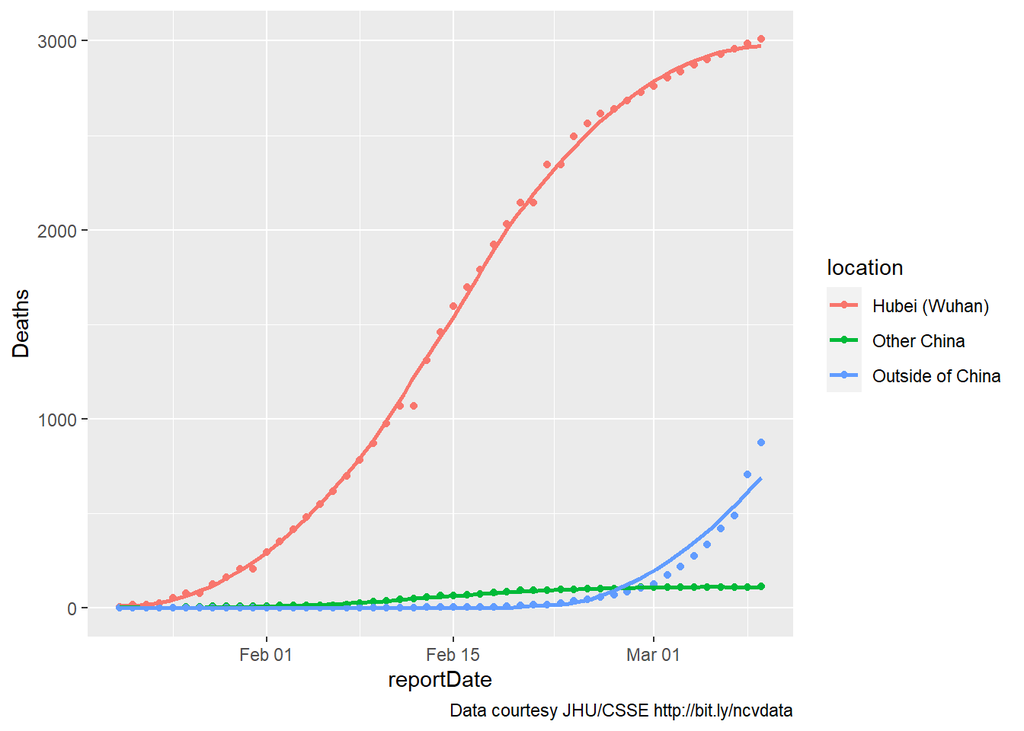

```r
myCaption <- " Data courtesy JHU/CSSE http://bit.ly/ncvdata"
coronaPlot0 <- coronaDataSimple %>%
  ggplot(aes(x=reportDate, y = Deaths, color = location)) +
  geom_point() +
  geom_smooth(se = FALSE) +
  labs(caption = myCaption)
coronaPlot0
```

### Adding recovered cases

Here, recovered cases and added to the plot.

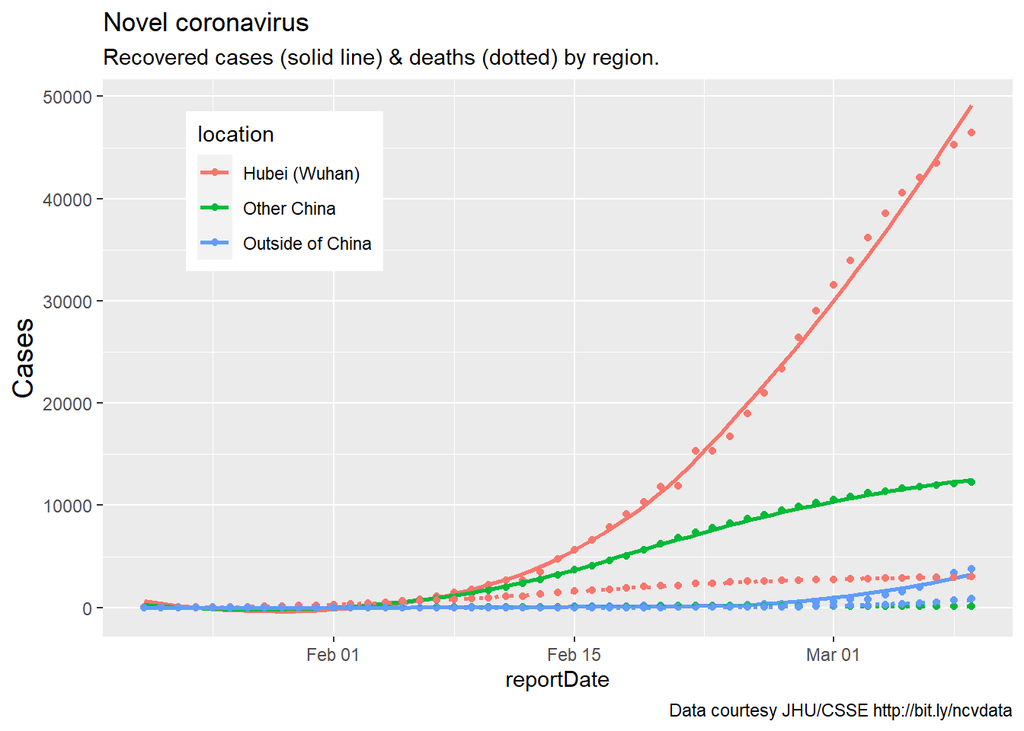

```r
mySubtitle <- paste0(
         "Recovered cases (solid line) & deaths (dotted) by region.")
myCaption <- " Data courtesy JHU/CSSE http://bit.ly/ncvdata"
coronaPlot1 <- coronaDataSimple %>%
  ggplot(aes(x=reportDate, color = location)) +
  geom_point(aes(y=Recovered)) +
  geom_smooth(aes(y=Recovered), se = FALSE,
              linetype = "solid") +
  geom_point(aes(y=Deaths)) +
  geom_smooth(aes(y=Deaths), se = FALSE,
              linetype = "dotted") +
#  scale_y_continuous(trans=pseudolog10_trans) +
#  geom_line(aes(y=Deaths,
#                color = location),
#            linetype = "dotted") +
  theme(axis.title.y =
        element_text(angle = 90,
                     vjust = 1,size = 14),
        legend.position = (c(.2,.8))) +
  labs(title = "Novel coronavirus",
       subtitle = mySubtitle,
       y = "Cases",
       caption = myCaption)
coronaPlot1
```

### Plotting confirmed cases

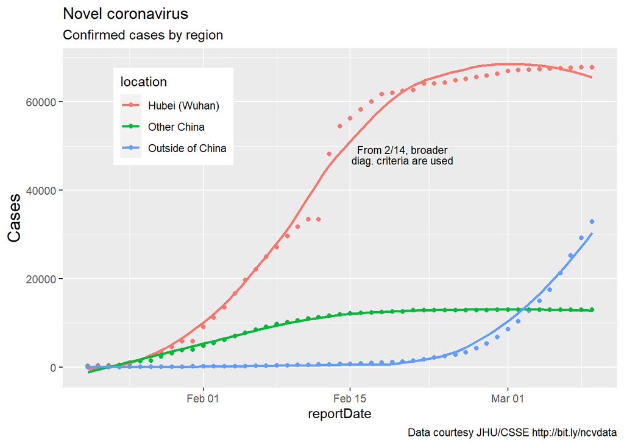

```r
#In this figure, data for confirmed cases are shown (only the interactive version is included here). :
mySubtitle <- paste0(
         "Confirmed cases by region")
coronaPlot2 <- coronaDataSimple %>%
  ggplot(aes(x=reportDate, color = location)) +
  geom_point(aes(y=Confirmed)) +
  geom_smooth(aes(y=Confirmed), se = FALSE,
              linetype = "solid") +
# adding a text block
# The code for this is clumsy
# the cleaner geom_label does not work correctly with plotly
#  annotate("rect",ymin=46000,ymax=50000,
##           xmin=date("2020-02-06"), xmax=date("2020-02-12"),
#           fill="white") +
  annotate("text", x=date("2020-02-20"), y=49200,
           label = "From 2/14, broader",
           size = 3) +
  annotate("text", x=date("2020-02-20"), y=46800,
           label = "diag. criteria are used",
           size = 3) +
  theme(axis.title.y =
        element_text(angle = 90,
                     vjust = 1,size = 14),
        legend.position = (c(.2,.8))) +
  labs(title = "Novel coronavirus",
       subtitle = mySubtitle,
       y = "Cases",
       caption = myCaption)
coronaPlot2
```

### Looking at the rate of growth in and out of China

In these plots, data for all three measures (Confirmed, Deaths, and Recovered) are plotted using log scales, and results are compared for China and the rest of the world. The log scales obscure the substantial difference in numbers in the two plots (as seen in the prior graphs). They do, however, allow a comparison of the shape of the trends in the two places and for the different types of cases. In China, the number of confirmed cases and deaths has leveled (while recovered cases continues to rise). The results for the rest of the world - though still increasing - are, perhaps, lagged roughly a month behind.

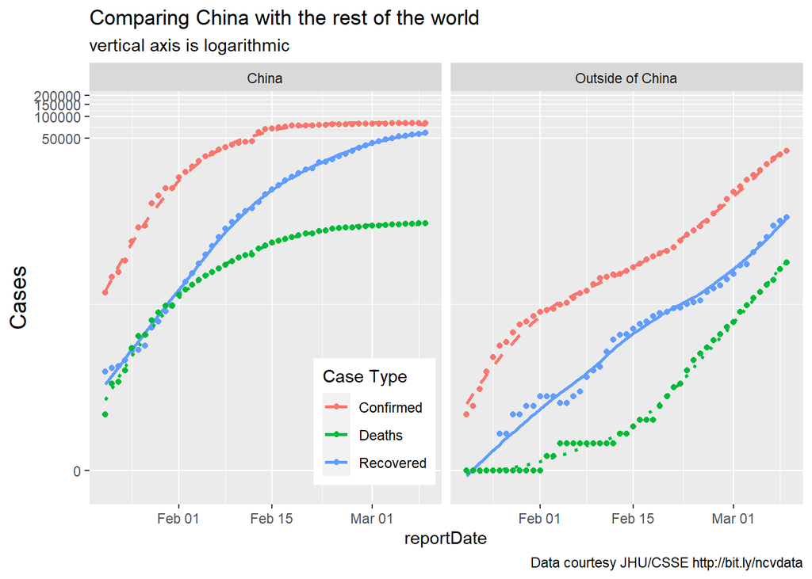

```r
# reducing three groups to two
coronaDataSimple2 <- coronaDataSimple %>%
  mutate(location = case_when(
    location == "Hubei (Wuhan)" ~ "China",
    location == "Other China" ~ "China",
    location == "Outside of China" ~ "Outside of China")) %>%
  group_by(location,reportDate) %>%
  summarize(Confirmed = sum(Confirmed),
            Deaths = sum(Deaths),
            Recovered = sum(Recovered)) %>%
  ungroup()

mySubtitle <- paste0(
         "vertical axis is logarithmic")
myCaption <- " Data courtesy JHU/CSSE http://bit.ly/ncvdata"
coronaPlot3 <- coronaDataSimple2 %>%
#  dplyr::filter(location == "China") %>%
  ggplot(aes(x=reportDate)) +
# three variables
  geom_point(aes(y=Recovered, color = "Recovered")) +
  geom_smooth(aes(y=Recovered, color = "Recovered"),
              se = FALSE, linetype = "solid") +
  geom_point(aes(y=Deaths, color = "Deaths")) +
  geom_smooth(aes(y=Deaths, color = "Deaths"),
              se = FALSE, linetype = "dotted") +
  geom_point(aes(y=Confirmed, color = "Confirmed")) +
  geom_smooth(aes(y=Confirmed, color = "Confirmed"),
              se = FALSE, linetype = "dashed") +
# log scale (pseudo becaue log 0 is inf)
  scale_y_continuous(trans=pseudolog10_trans,
                     limits = c(-1,125000)) +
  theme(axis.title.y =
        element_text(angle = 90,
                     vjust = 1,size = 14),
        legend.position = (c(.4,.2))) +
# kludge to change legend title
    scale_colour_discrete("Case Type") +
  labs(title = "Comparing China with the rest of the world",
       fill = "Case type",
       subtitle = mySubtitle,
       y = "Cases",
      caption = myCaption)
coronaPlot3 + facet_grid(cols = vars(location))
```

### Is the rest of the world one month behind China?

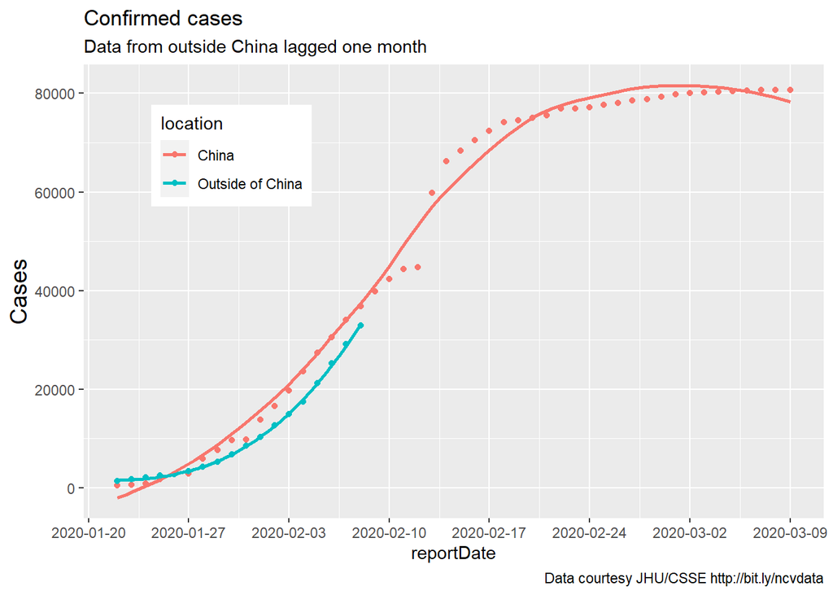

```r
# reducing three groups to two
coronaDataSimple3 <- coronaDataSimple2 %>%
  mutate(reportDate = case_when
          (location == "Outside of China" ~ reportDate - 30,
           location == "China" ~ reportDate)) %>%
  group_by(location,reportDate) %>%
  summarize(Confirmed = sum(Confirmed),
            Deaths = sum(Deaths),
            Recovered = sum(Recovered)) %>%
  ungroup()

mySubtitle <- paste0(
         "Data from outside China lagged one month")
myCaption <- " Data courtesy JHU/CSSE http://bit.ly/ncvdata"
coronaPlot4 <- coronaDataSimple3 %>%
  ggplot(aes(x=reportDate, color = location)) +
  scale_x_date(date_breaks = "1 week",
                 limits = as.Date(c('2020-01-22',today()))) +
  geom_point(aes(y=Confirmed)) +
  geom_smooth(aes(y=Confirmed), se = FALSE,
              linetype = "solid") +
  theme(axis.title.y =
        element_text(angle = 90,
                     vjust = 1,size = 14),
        legend.position = (c(.2,.8))) +
  labs(title = "Confirmed cases",
       subtitle = mySubtitle,
       y = "Cases",
       caption = myCaption)
coronaPlot4
```

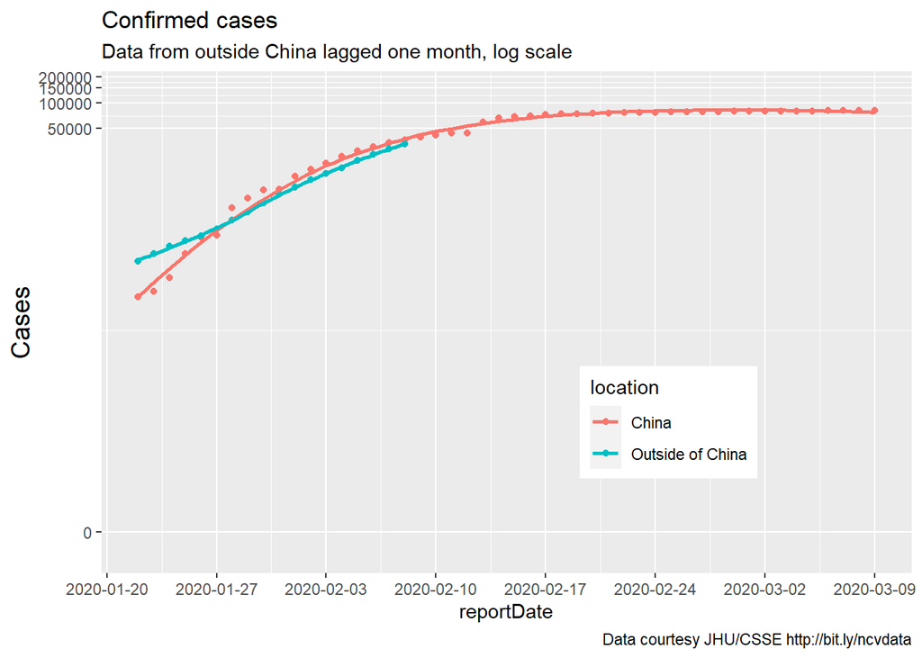

```r
mySubtitle <- paste0(
         "Data from outside China lagged one month, log scale")
coronaPlot5 <- coronaDataSimple3 %>%
  ggplot(aes(x=reportDate, color = location)) +
  scale_x_date(date_breaks = "1 week",
                 limits = as.Date(c('2020-01-22',today()))) +
  scale_y_continuous(trans=pseudolog10_trans,
                     limits = c(-1,125000)) +
  geom_point(aes(y=Confirmed)) +
  geom_smooth(aes(y=Confirmed), se = FALSE,
              linetype = "solid") +
  theme(axis.title.y =
        element_text(angle = 90,
                     vjust = 1,size = 14),
        legend.position = (c(.7,.3))) +
  labs(title = "Confirmed cases",
       subtitle = mySubtitle,
       y = "Cases",
       caption = myCaption)
coronaPlot5
```

### Some questions

1. Grab the code and try to run it yourself. What problems (if any) did you encounter?
2. Can you reverse-engineer the code? Where is it confusing? (remember the 15 minute rule).
3. What is the relationship between ‘confirmed cases’ and ‘deaths’? Which appears to be increasing more quickly? Is this cause for optimism?
4. Can you improve on these plots?

### Additional notes

If you are interested in looking at additional epidemiological datasets and how they might be looked at in R, consider this source by Tomás J. Aragón (https://bookdown.org/medepi/phds/). For Plotly in R, check out https://plotly-r.com/

This document was modified February 3 because of new Googlesheet link and altered variable names, on Feb 5 because of a new URL for the data and additional changes in the variable name for date, and Feb 7 to (a) remove need for OAuth and (b) separate Wuhan from other China. On Feb 9, additional data cleaning was performed and interactive plots were added. On February 11, the code was rewritten to read files from a Github repo rather than Google Sheets. Minor changes and additions were made in late February and early March. These include dropping the (buggy) interactive graphs and adding the side-by-side graph for the log data. ```